# CAPM

Omer Caliskan

18/07/2019

```r
install.packages("readxl", repos='http://cran.us.r-project.org')
install.packages("kableExtra", repos='http://cran.us.r-project.org')
library("readxl")
library("kableExtra")
```

## Capital Asset Pricing Model

CAPM is an important model in finance. It explains the variance of a security’s rate of return as a function of rate of return on market portfolio, which consists of all publicly traded stocks.

$r_{j}-r_{f}=\beta_{j}(r_{m}-r_{f})$

$r_{j}$ and $r_{f}$ are the returns to chosen security and the risk-free rate, respectively. $r_{m}$ is the return on the market portfolio, and $\beta_{j}$ is the security’s ‘beta’ value. It reveals the stock’s volatility by measuring the sensitivity of the security’s return to variation in the whole stock market.

The rate of return on an investment is measured relative to its opportunity cost, which is the return on a risk-free asset. The difference is called the risk premium. That’s why we include the return on risk-free asset in the model.

A beta less than 1 indicates that stock is defensive since its variation is less than the market’s. A beta greater than 1 indicates an aggressive stock.

## Data

```r
capm5 <- read_xlsx("C:\\Users\\omer\\Desktop\\Econ_425\\poe5xlsx\\capm5.xlsx", sheet=1)
head(capm5)
```

```
## # A tibble: 6 x 10
##   date   time       ge      ibm   ford     msft     dis     xom      mkt
##   <chr> <dbl>    <dbl>    <dbl>  <dbl>    <dbl>   <dbl>   <dbl>    <dbl>
## 1 30JA~     1  0.0562  -0.0562  0.0588  0.154    0.0809 -0.0306  0.00450
## 2 27FE~     2  0.00323  0.0596  0.109   0.136    0.0474  0.0817  0.0733
## 3 31MA~     3  0.112   -0.00539 0.146   0.0560  -0.0463  0.0608  0.0513
## 4 30AP~     4 -0.0116   0.116   0.0862  0.00698  0.168   0.0804  0.0109
## 5 29MA~     5 -0.0213   0.0159  0.132  -0.0589  -0.0908 -0.0295 -0.0257
## 6 30JU~     6  0.0900  -0.0229  0.137   0.278   -0.0723  0.0124  0.0319
## # ... with 1 more variable: riskfree <dbl>
```

## Analysis

To be able to compare risk-premiums, rather than returns without including their opportunity costs, I will first create vectors for risk-premiums. Then, we can run linear regressions to compare each stocks return against market portfolio’s.

```r
# measure the risk-premium for market portfolio
market_return <- capm5$mkt - capm5$riskfree

# measure the risk-premium for each stock
ge_return <- capm5$ge - capm5$riskfree
ibm_return <- capm5$ibm - capm5$riskfree
ford_return <- capm5$ford - capm5$riskfree
msft_return <- capm5$msft - capm5$riskfree
dis_return <- capm5$dis - capm5$riskfree
xom_return <- capm5$xom - capm5$riskfree

# build the model for each stock
CAPM_ge = lm(ge_return~ 0+market_return, capm5)
CAPM_ibm = lm(ibm_return~ 0+market_return, capm5)
CAPM_ford = lm(ford_return~ 0+market_return, capm5)
CAPM_msft = lm(msft_return~ 0+market_return, capm5)
CAPM_dis = lm(dis_return~ 0+market_return, capm5)
CAPM_xom = lm(xom_return~ 0+market_return, capm5)
```

## Plots

Here are the plots to visualize the relationship between market’s return and that of our stock’s. Steepness of the lines indicate the responsiveness level of a stock to market’s movements. The steeper the line the more aggressive the stock is.

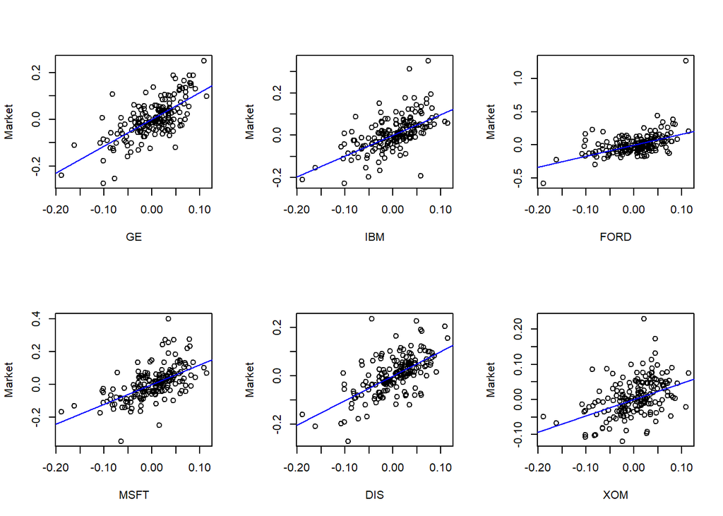

```r
par(mfrow=c(2,3))
plot(market_return, ge_return, xlab="GE", ylab="Market")
abline(CAPM_ge, col="blue")
plot(market_return, ibm_return, xlab="IBM", ylab="Market")
abline(CAPM_ibm, col="blue")
plot(market_return, ford_return, xlab="FORD", ylab="Market")
abline(CAPM_ford, col="blue")
plot(market_return, msft_return, xlab="MSFT", ylab="Market")
abline(CAPM_msft, col="blue")
plot(market_return, dis_return, xlab="DIS", ylab="Market")
abline(CAPM_dis, col="blue")
plot(market_return, xom_return, xlab="XOM", ylab="Market")
abline(CAPM_xom, col="blue")
```

## Beta Values

```r
stocks <- c("ge", "ibm", "ford", "msft", "dis", "xom")
beta_values <- c(coef(CAPM_ge)[[1]],coef(CAPM_ibm)[[1]] ,coef(CAPM_ford)[[1]] ,coef(CAPM_msft)[[1]] ,coef(CAPM_dis)[[1]] ,coef(CAPM_xom)[[1]])
df <- data.frame(stocks,beta_values)
kable(df, format = "html", caption = "Beta Values") %>%
  kable_styling(bootstrap_options = "striped",
                full_width = F) %>%
  add_header_above(c(" ", ""))
```

Beta Values

| stocks | beta_values |
| --- | --- |
| ge | 1.1467633 |
| ibm | 0.9843954 |
| ford | 1.6667168 |
| msft | 1.2058695 |
| dis | 1.0128190 |
| xom | 0.4630727 |

According to the table, Ford is the most aggressive stock and Exxon-Mobile is the most defensive one.